# SMART Competition Data Report

Authors

Lukas Wallrich

Lukas Röseler

Flavio Azevedo

Sarah Ashcroft-Jones

Sriraj Aiyer

Leonardo Bergmann

Ognjen Bobičić

Kathryn Bottitta

Antony Casula

Adira Daniel

Teshome Kebede Deressa

Corinna Gemmecke

Marta Kołczyńska

Sebastian Kurten

Radoslaw P. Lach

Diego Manriquez-Robles

Brinna E. Mawhinney

Maureen Osano

Nikita Otstavnov

Aleksandr Pravednikov

Husnain Raza

Hakile Resulbegoviq

Jessica Röseler

Julia Fabienne Sandkühler

Alejandro Sandoval-Lentisco

Sophie Schüller

Roksana Sobolak

Maria Stogianni

Mariem Younssi

Published

November 30, 2025

[figure not shown]

[figure not shown]

The Center for Open Science and the Framework for Open and Reproducible Research Training are [collaborating for the SMART competition](https://www.cos.io/blog/cos-and-forrt-partner-to-increase-discoverability-and-usability-of-replication-evidence). As a result, FORRT will provide validated training data to competition participants. This report describes the data provided alongside it.

### Delivery of Data

- Start date: October 21, 2024
- 300 entries by January 31, 2025 (deadline extended to February 7, 2025)
- ~400 additional entries until September 2025
- Final dataset delivery by the end of November 2025

### Changelog

**Click here to see the full changelog for the dataset and report**

**Version 1.1 (2025-03-27)**

- New entries have been added.
- Effect size conversion functions were updated. The last version of the dataset included an error where - using the esc R package - some functions did and some did not drop signs. We apologise for missing this and opened an [issue](https://github.com/strengejacke/esc/issues/17) recommending consistency in the esc R package.
- We made more specific that some effect sizes lack information about the direction or pattern of the effect (section “computation of Standardized Effect Sizes”)

**Version 1.2 (2025-04-23)**

- Study numbers have been changed to say 1 instead of NA when only one study was included in a report.
- Moved library functions to a different block to facilitate suppression of packages’ messages.
- Added plot on progress.

**Version 1.3 (2025-05-23)**

- A plot to observe the progression speed has been added.

**Version 1.4 (2025-06-05)**

- Added success criterion to dataset and codebook.

**Version 1.5 (2025-06-16)**

- Added preliminary plot with converted effect sizes.
- Updated description of variable fred_id to clarify why there are duplicate values for fred_id.

**Version 1.6 (2025-06-27)**

- Updated entry numbers.
- Synchronized with Github repository (FReD-data).
- Corrected effect size conversion table (F tests are never converted).
- Added point descriptions to the scatterplot including replication success colors (visible by hovering over them).
- Incorporated [cleaning script](https://raw.githubusercontent.com/forrtproject/FReD-data/refs/heads/main/clean_cos_fred.R).
- Made progress plot interactive (plotly)
- Corrected entry progress numbers (some of the past numbers were erroneous due to an erroneous entry counting function)

**Version 1.7 (2025-09-27)**

- Clarified subjective success coding based on replication authors’ interpretation (aka ground truth) and add distribution chart
- Rename outcome variables into `reported_success` and `statistical_success` to avoid risk of confusion and added outcome charts
- Rearranged the document to first describe the dataset and shift the internal process to the end

**Version 1.8 (2025-10-10)**

- Fixed numbering in `effect_id` so that they count rows within each `entry_id`
- Added `fred_id_old`, which is largely (!) in line with `fred_id` from versions up until 1.4 to facilitate merging

**Version 1.9 (2025-10-16)**

- Reformatted ground truth / `reported_success` plot
- Removed ~10 duplicate effects
- Added section with warnings and caveats for dataset users
- Normalized all doi to lowercase, as they are inconsistently reported but not case sensitive

**Version 2.0 (2025-11-30)**

### Terminology

The relation between an article reporting a replication study and the corresponding original study can be complex. The following terms allow for almost every combination of original and replication studies to be documented in the dataset.

| Term | Description |
| --- | --- |
| Entry | One entry consists of a pair of studies, one of which self-identifies as a replication of the other, using different data than the original study. The replication study investigates at least one centr… |
| Study | A study is an empirical investigation made in one of the reports. One entry usually consists of exactly two references/reports. Each of the references/reports can consist of multiple studies. |
| Row | One row in the database consists of one pair of original and replication effects that correspond to a claim made in the original study. In other words, one row is one pair of *findings*. |
| Claim | Each row must contain a claim that was made in the original report and that is tested again in the replication report. Multiple rows from one entry can have the same claim (e.g., a claim is tested usi… |

### Current Status

| Data source | Type | Quantity |
| --- | --- | --- |
| FORRT Coding | Coded rows (including discarded and non-validated) | 5386 |
| FORRT Coding | Validated rows | 2032 |
| FORRT Coding | Validated entries | 909 |
| FORRT Coding | New validated entries since last report | 220 |
| FORRT Coding | Original reports | 871 |
| FORRT Coding | Replication reports | 745 |
| COS Phase 1 Test Data (SCORE) | Validated rows | 132 |
| COS Phase 1 Test Data (SCORE) | Validated entries | 95 |
| COS Phase 1 Test Data (SCORE) | Original reports | 92 |
| COS Phase 1 Test Data (SCORE) | Replication reports | 89 |

[output cut: 1 more lines]

The following plot displays the progress (black dots and line) and the targets (red dots) that were agreed on. Note that these numbers were corrected in June 2025; earlier reports had included some double-counting.

[interactive chart not shown]

### Computation of Standardized Effect Sizes

Original studies and replications report effect sizes in a wide range of metrics. Where meaningful, we provide the reported values alongside a conversion to *r* (Pearson’s correlation coefficient), using the [function in the FReD R package](https://forrt.org/FReD/reference/convert_effect_sizes.html). However, this is not always possible or meaningful, particularly where effect sizes do not express an unconditional bivariate relationship (e.g., interaction effects or partial correlations), and where they do not encode the direction of an effect (e.g., R² or F-statistics). In these cases, the quantitative replication results will not show whether the pattern matches (e.g., two F test could be significant due to opposite interaction patterns). The table below shows how we have proceeded in this dataset. (NB: For the rows contributed by COS, we retained their effect size conversion that standardized a wider range of original effects on a case-by-case basis.)

| Action | Effect Size Types |
| --- | --- |
| Used as correlation | r, Phi |
| Converted to correlation | Odds Ratio, Cohen’s d, Hedges’s g, directional test statistics: t test Z test |
| Did not convert, but provide [function](https://forrt.org/FReD/reference/convert_effect_sizes.html) if analysts wish to convert | R², Eta squared, Cohen’s f, Cohen’s f², non-directional test statistics: F with df1 = 1 and χ² with df = 1 |
| No conversion | Partial correlation, Cohen’s dz, Cramer’s V, Omega, regression coefficients, partial Eta squared, unstandardised mean/median differences, other test statistics (e.g., F with df1 > 1, proportion test, … |

## Replication success

Replication success can be defined in different ways. Here, we provide two variables - one that is based on the authors’ subjective interpretation of the replication results *at the study/entry level* and one that is based on a statistical criterion at the level of *individual claims*.

### Statistical success variable

There are many different statistical indicators of replication success (many of which can be calculated with the [FReD package](https://forrt.org/FReD/articles/success_criteria.html)). However, for this project COS defines success as a significant result *in the same direction* as the original finding.

This is not trivial to derive from the data where effect sizes are not directional. We provide a `statistical_success` variable that is defined as follows:

- `TRUE` when the replication is significant (based on the reported p-value, at alpha = .05) and the reported effect size is directional and in the same direction as the original. Note that this includes cases where effect sizes cannot be converted into a common metric, such as regression coefficients.
- `FALSE` when the replication is not significant, or the reported effect size is directional and in the opposite direction as the original.
- `NA` when original and/or replication effect sizes are not directional (e.g, Eta squared, F-tests, R²), when the original study was not significant, or when the statistical significance of original or replication effect is unclear.

NB: Given that the SCORE data always contains directional correlation coefficients, statistical_success is defined for all SCORE rows, even where the originally reported effect sizes were non-directional.

**Click here for a list of directional and non-directional effect size types**

- *Directional:* odds ratios, correlations (r and phi), Cohen’s d / Hedges’ g, t-test, Z, regression weights (b, beta), mean difference
- *Non-directional:* η² (and partial), F-test, R²

Out of 2164 rows, `statistical_success` could be calculated for 901 rows. Among these, 49.5% were statistically successful (significant in the same direction) and 50.5% could be considered failures.

[interactive chart not shown]

### Author’s reported success variable

We reviewed the reports to identify how authors interpreted their results. This is coded based on the abstract where possible, and the conclusion/discussion/results section otherwise. The variable `reported_success` is coded as follows:

- `successful` when the authors interpret their replication as successful (e.g., “we successfully replicated…”)
- `failed` when the authors interpret their replication as unsuccessful (e.g., “we failed to replicate…”)
- `mixed` when the authors describe their results as mixed or as a partial replication

There are a few more specific categories that are used less frequently:

- `uninformative` when the authors explicitly describe their results as uninformative, e.g. due to a small sample size
- `statistically successful but flawed` when the authors replicate the original finding but *primarily* do so to show that the method is flawed, and that an alternative analysis yields different results
- `descriptive only` when authors describe patterns but do not draw comparative conclusions.

The variables `reported_success_quote` and `reported_success_quote_source` provide the quote (or decision rule) that was used to code the variable and the section of the report where it was found. NB: For SCORE, the decision rule was to base conclusions on the significance of the focal test, so that reported_success corresponds to statistical_success in these cases, and quotes are not provided.

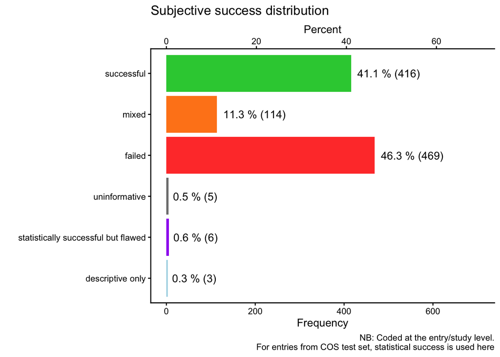

## Codebook

The finalized dataset includes the variables that COS and FORRT agreed on as well as further variables that FORRT found necessary to understand the entered value. More detailed datasets are available upon request. A synthesis of the current version of the FORRT Replication Database with the new data format is planned for fall 2025.

NB: Beware that the `entry_id` and `effect_id` variables are *not* stable across versions of the dataset. They are re-generated for each version of the dataset to ensure that entries and effects are numbered consecutively. If you want to identify entries uniquely across versions of the data, it is better to rely on a combination of `doi_o`, `study_o`, `doi_r` (and `url_r`), and `study_r`.

| Variable | Description |
| --- | --- |
| entry_id | Consecutive number for replication reference and corresponding rows (rows with the same value correspond to the same entry) |
| effect_id | Consecutive number for different rows that are part of one entry |
| fred_id | Corresponding entry in the FORRT Replication Database (FReD), can be used to filter the crowdsourced FReD data for additional studies. |
| fred_id_old | Less consistent version of fred_id - should only be used to combine data with earlier versions of this dataset |
| ref_o | reference of original report (APA style) |
| doi_o | DOI of original report, without URL prefix, so starting with 10.xx |
| study_o | Number of study in paper, e.g., 1 or 2A |
| ref_r | reference of replication report (APA style) |
| doi_r | DOI of replication report, without URL prefix, so starting with 10.xx |
| url_r | Link to replication results - only when DOI missing or where DOI refers to aggregate report |

[output cut: 33 more lines]

## Validated Dataset

**Click here to see the full list of coded studies**

| ref_o | ref_r | discipline |
| --- | --- | --- |
| Abel, E. L., &amp; Kruger, M. L. (2010). Smile Intensity in Photographs Predicts Longevity. Psychological Science, 21(4), 542–544. https://doi.org/10.1177/0956797610363775 | Dufner, M., Brümmer, M., Chung, J. M., Drewke, P. M., Blaison, C., &amp; Schmukle, S. C. (2017). Does Smile Intensity in Photographs Really Predict Longevity? A Replication and Extension of Abel and K… | Social Psychology |
| Abeler, J., Falk, A., Goette, L., &amp; Huffman, D. (2011). Reference Points and Effort Provision. American Economic Review, 101(2), 470–492. https://doi.org/10.1257/aer.101.2.470 | Camerer, C. F., Dreber, A., Forsell, E., Ho, T.-H., Huber, J., Johannesson, M., Kirchler, M., Almenberg, J., Altmejd, A., Chan, T., Heikensten, E., Holzmeister, F., Imai, T., Isaksson, S., Nave, G., P… | Economics |
| Abend, R., Bajaj, M. A., Matsumoto, C., Yetter, M., Harrewijn, A., Cardinale, E. M., Kircanski, K., Lebowitz, E. R., Silverman, W. K., Bar-Haim, Y., Lazarov, A., Leibenluft, E., Brotman, M., &amp; Pin… | Byrne, M. E., Kirschner, S., Harrewijn, A., Abend, R., Lazarov, A., Liuzzi, L., Kircanski, K., Haller, S. P., Bar-Haim, Y., &amp; Pine, D. S. (2024). Eye-tracking measurement of attention bias to soci… | Psychopathology |
| Abeyta, A. A., Routledge, C., Kersten, M., &amp; Cox, C. R. (2016). The existential cost of economic insecurity: Threatened financial security undercuts meaning. The Journal of Social Psychology, 157(… | O’Donnell, M., Dev, A. S., Antonoplis, S., Baum, S. M., Benedetti, A. H., Brown, N. D., Carrillo, B., Choi, A. L., Connor, P., Donnelly, K., Ellwood-Lowe, M. E., Foushee, R., Jansen, R., Jarvis, S. N.… | Social Psychology |
| Abrams, R. A., Davoli, C. C., Du, F., Knapp, W. H., &amp; Paull, D. (2008). Altered vision near the hands. Cognition, 107(3), 1035–1047. https://doi.org/10.1016/j.cognition.2007.09.006 | Schultheis, H., &amp; Carlson, L. A. (2013). Determinants of attentional modulation near the hands. Frontiers in Psychology, 4. https://doi.org/10.3389/fpsyg.2013.00858 | Cognitive Psychology |
| Ackerman, J. M., Nocera, C. C., &amp; Bargh, J. A. (2010). Incidental Haptic Sensations Influence Social Judgments and Decisions. Science, 328(5986), 1712–1715. https://doi.org/10.1126/science.1189993 | Camerer, C. F., Dreber, A., Holzmeister, F., Ho, T.-H., Huber, J., Johannesson, M., Kirchler, M., Nave, G., Nosek, B. A., Pfeiffer, T., Altmejd, A., Buttrick, N., Chan, T., Chen, Y., Forsell, E., Gamp… | Social Psychology |
| Ackerman, J., &amp; Field, L. (2011). The Gender Asymmetric Effect of Intimate Partner Violence on Relationship Satisfaction. Violence and Victims, 26(6), 703–724. https://doi.org/10.1891/0886-6708.26… | Ackerman, J. M. (2012). The Relevance of Relationship Satisfaction and Continuation to the Gender Symmetry Debate. Journal of Interpersonal Violence, 27(18), 3579–3600. https://doi.org/10.1177/0886260… | Social Psychology |
| Adcock, R. A., Thangavel, A., Whitfield-Gabrieli, S., Knutson, B., &amp; Gabrieli, J. D. E. (2006). Reward-Motivated Learning: Mesolimbic Activation Precedes Memory Formation. Neuron, 50(3), 507–517. … | Spaniol, J., Schain, C., &amp; Bowen, H. J. (2013). Reward-Enhanced Memory in Younger and Older Adults. The Journals of Gerontology Series B: Psychological Sciences and Social Sciences, 69(5), 730–740… | Cognitive Psychology |
| Addis, D. R., Wong, A. T., &amp; Schacter, D. L. (2008). Age-Related Changes in the Episodic Simulation of Future Events. Psychological Science, 19(1), 33–41. https://doi.org/10.1111/j.1467-9280.2008.… | (2015). Estimating the reproducibility of psychological science. Science, 349(6251). https://doi.org/10.1126/science.aac4716 | Social Psychology |
| Aguado, L., Garcia-Gutierrez, A., &amp; Serrano-Pedraza, I. (2009). Symmetrical interaction of sex and expression in face classification tasks. Perception &amp;amp; Psychophysics, 71(1), 9–25. https:/… | Lipp, O. V., Karnadewi, F., Craig, B. M., &amp; Cronin, S. L. (2015). Stimulus set size modulates the sex–emotion interaction in face categorization. Attention, Perception, &amp;amp; Psychophysics, 77… | Cognitive Psychology |

[output cut: 874 more lines]

## Some warnings and caveats

- **Study numbers**: Please note that for large scale replication projects, there are no consistently reported study numbers. In this dataset, we use study numbers to consistently identify them but they do not necessarily to reflect the study order in the replication article or the associated dataset.
- **Pre-Prints**: It is possible that some replication studies that are coded as preprints have been published in a journal in the meantime.
- **Eta-squared**: Our [conversion function](https://forrt.org/FReD/reference/convert_effect_sizes.html) converts eta-squared but not partial eta-squared. It is possible that authors misreported one as the other.
- **`entry_id` and `effect_id` variables are *not* stable across versions of the dataset**. They should thus not be used to identify entries over time. They are re-generated for each version of the dataset to ensure that entries and effects are numbered consecutively. If you want to identify entries uniquely across versions of the data, it is better to rely on a combination of `doi_o`, `study_o`, `doi_r` (and `url_r`), and `study_r`.
- **Selection of rows:** A statistical result in a replication can be assigned to two different original results from the same paper (e.g., when the original only reported separate effects for sub-samples but replication focused on total sample), and an original result can be combined with multiple replication results. Also, matched effects are not comprehensive but selected by the coders for being linked to the relevant claim. Therefore, rows should not be treated as independent.
- **Two data sources:** The dataset combines two data sources (FORRT Replication Database and SCORE data, used by COS as test data in Phase 1 of the competition). The SCORE data includes effect size conversions that were done by COS on a case-by-case basis, which may differ from the general approach taken in the FORRT Replication Database. Specifically, their conversion from Cohen’s *d* to *r* took relative group sizes into account, which diverges slightly from the more general formula used in the FORRT data. SCORE also only considered *key* claims in papers, while the FORRT claims were selected more broadly. Nevertheless, the entries should be comparable across the two data sources.

## Internal Process

Entries were initially drawn from the [FORRT Replication Database](https://forrt-replications.shinyapps.io/fred_explorer/), which consists of crowdsourced data that has been single-coded and partially validated, an unsystematic list of additional replications we have maintained, and a broad literature search. A snapshot description of the FORRT Replication Database from October 2023 was published [here](https://doi.org/10.5334/jopd.101). Given that psychology has conducted the largest replication projets to date, the dataset is biased towards psychology, but we aimed to include other fields where possible.

Each entry is assigned to two FReD Data Curators, who independently complete all variables. They are collected by the FReD-team in a Google Spreadsheet for validation and run through a [cleaning-script](https://raw.githubusercontent.com/forrtproject/FReD-data/refs/heads/main/clean_cos_fred.R). Most of the time, the values from one Data Curator are revised and chosen and the others are superseded. It is possible to choose a combination or all of the rows of an entry if different effects were coded by the FReD Data Curators.